# Bayesian Analysis Project

Selina Crawford

# Install and load necessary packages

```r
install.packages("bayesrules")
install.packages("tidybayes")
install.packages("tidyverse")
install.packages("broom")
install.packages("broom.mixed")
install.packages("readxl")
library(tidyverse)
```

```r
library(bayesrules)
library(ggplot2)
library(rstanarm)
library(bayesplot)
library(tidybayes)
library(broom)
library(broom.mixed)
library(rstan)
library(janitor)
library(readxl)
```

# Dataset

This dataset comes from Spotify’s API on all albums listed on Spotify for Taylor Swift. It was complied by Kaggle.com user Jarred Priester. (link: https://www.kaggle.com/datasets/jarredpriester/taylor-swift-spotify-dataset) It includes 582 entries that breakdown 363 of Taylor Swift’s songs by name, album, danceability, energy, tempo, valence, and popularity, among other information. This project aims to use this data to create a model that predicts the popularity of a song when given values for the other variables.

Upload data and removed columns irrelevant to this analysis such as release date, track number, song id, ect.

```r
taylor_swift_spotify <- read_excel("taylor_swift_spotify.xlsx")
taylor_grouped <- taylor_swift_spotify[c(1, 7:17)]
```

Simplify the data by grouping together all of the songs that have the same name, as many of the songs are duplicates as they appear in multiple albums.

```r
taylor_grouped %>%
  group_by(name) %>%
  tally(n ='num_duplicates')
```

| name | num_duplicates |
| --- | --- |
| "Slut!" (Taylor's Version) (From The Vault) | 2 |
| ...Ready For It? | 1 |
| 22 | 3 |
| 22 (Taylor's Version) | 1 |
| A Perfectly Good Heart | 1 |
| A Place in this World | 2 |
| Afterglow | 1 |
| All Too Well | 3 |
| All Too Well (10 Minute Version) (Taylor's Version) (From The Vault) | 1 |
| All Too Well (Taylor's Version) | 1 |

[output cut: 353 more lines]

```r
taylor_final <- taylor_grouped %>%
  group_by(name) %>% summarize(acousticness = mean(acousticness),
  danceability = mean(danceability), energy = mean(energy), liveness = mean(liveness),
  loudness = mean(loudness), speechiness = mean(speechiness), tempo = mean(tempo),
  valence = mean(valence), popularity = mean(popularity), duration_ms = mean(duration_ms))
  taylor_final %>%
    head(n=5)
```

| name | acousticness | danceability | energy | liveness | loudness | speechiness | tempo | valence | popularity | duration_ms |
| --- | --- | --- | --- | --- | --- | --- | --- | --- | --- | --- |
| "Slut!" (Taylor's Version) (From The Vault) | 0.330000 | 0.6210000 | 0.415 | 0.06340000 | -13.187000 | 0.05430000 | 77.978 | 0.313 | 70.5 | 180381.0 |
| ...Ready For It? | 0.052700 | 0.6130000 | 0.764 | 0.19700000 | -6.509000 | 0.13600000 | 160.015 | 0.417 | 82.0 | 208186.0 |
| 22 | 0.002280 | 0.6596667 | 0.730 | 0.05673333 | -6.562333 | 0.03776667 | 104.001 | 0.671 | 49.0 | 231457.7 |
| 22 (Taylor's Version) | 0.000443 | 0.6420000 | 0.695 | 0.07530000 | -5.620000 | 0.02810000 | 103.984 | 0.642 | 76.0 | 230960.0 |
| A Perfectly Good Heart | 0.003490 | 0.4830000 | 0.751 | 0.12800000 | -5.726000 | 0.03650000 | 156.092 | 0.268 | 53.0 | 220146.0 |

# Data Model

Fit a Bayesian generalized linear model, with popularity as the response variable.

```r
as.data.frame(taylor_final)
```

| name | acousticness | danceability | energy | liveness | loudness | speechiness | tempo | valence | popularity | duration_ms |
| --- | --- | --- | --- | --- | --- | --- | --- | --- | --- | --- |
| "Slut!" (Taylor's Version) (From The Vault) | 0.3300000000 | 0.6210000 | 0.4150000 | 0.06340000 | -13.187000 | 0.05430000 | 77.97800 | 0.3130000 | 70.50000 | 180381.0 |
| ...Ready For It? | 0.0527000000 | 0.6130000 | 0.7640000 | 0.19700000 | -6.509000 | 0.13600000 | 160.01500 | 0.4170000 | 82.00000 | 208186.0 |
| 22 | 0.0022800000 | 0.6596667 | 0.7300000 | 0.05673333 | -6.562333 | 0.03776667 | 104.00100 | 0.6710000 | 49.00000 | 231457.7 |
| 22 (Taylor's Version) | 0.0004430000 | 0.6420000 | 0.6950000 | 0.07530000 | -5.620000 | 0.02810000 | 103.98400 | 0.6420000 | 76.00000 | 230960.0 |
| A Perfectly Good Heart | 0.0034900000 | 0.4830000 | 0.7510000 | 0.12800000 | -5.726000 | 0.03650000 | 156.09200 | 0.2680000 | 53.00000 | 220146.0 |
| A Place in this World | 0.0543000000 | 0.5745000 | 0.7720000 | 0.32350000 | -2.905000 | 0.03235000 | 115.00650 | 0.4330000 | 41.00000 | 200640.0 |
| Afterglow | 0.1300000000 | 0.7560000 | 0.4490000 | 0.11400000 | -8.746000 | 0.03440000 | 111.01100 | 0.3990000 | 74.00000 | 223293.0 |
| All Too Well | 0.0404000000 | 0.5556667 | 0.6076667 | 0.12766667 | -7.803000 | 0.02596667 | 124.07767 | 0.3303333 | 46.00000 | 328737.7 |
| All Too Well (10 Minute Version) (Taylor's Version) (From The Vault) | 0.2740000000 | 0.6310000 | 0.5180000 | 0.08800000 | -8.771000 | 0.03030000 | 93.02300 | 0.2050000 | 80.00000 | 613026.0 |
| All Too Well (Taylor's Version) | 0.0171000000 | 0.4400000 | 0.5280000 | 0.23400000 | -7.809000 | 0.03170000 | 185.97200 | 0.1320000 | 71.00000 | 329160.0 |

[output cut: 353 more lines]

```r
taylor_model <- stan_glm(
  popularity ~ acousticness + danceability + energy + liveness + loudness + speechiness + tempo + valence,
  family = gaussian(), data = taylor_final,
  prior_intercept = normal(50,20),
  prior= normal(0, 1, autoscale=TRUE),
  prior_aux= exponential(1, autoscale= TRUE),
  chains= 4, iter= 5000*2, seed= 84735)
```

Without looking at the data, I would assume the average song has a popularity score of 50, and popularity ranges from 10 to 90. Thus, the prior used for the intercept is (50,20).

The MCMC will run with 4 chains of 10,000 iterations to increase the liklihood that it will be sufficiently mixed.

# Model Adequacy Checking

Run trace and autocorrelation plots to ensure the posterior simulation has sufficiently mixed and stabilized.

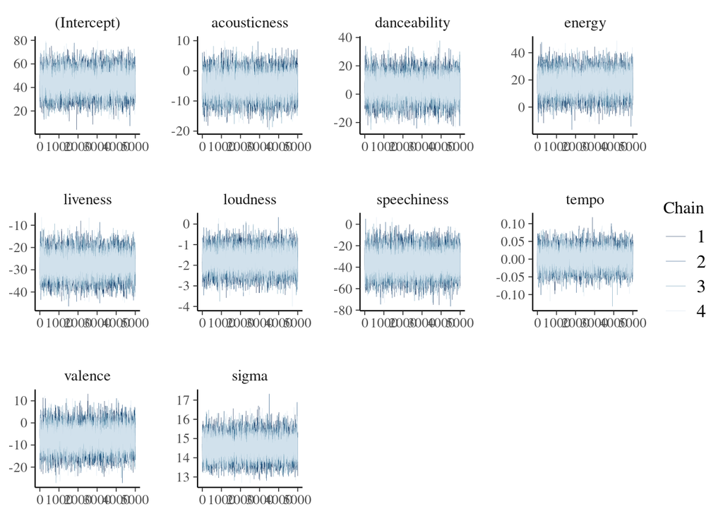

```r
mcmc_trace(taylor_model, size= 0.3)
```

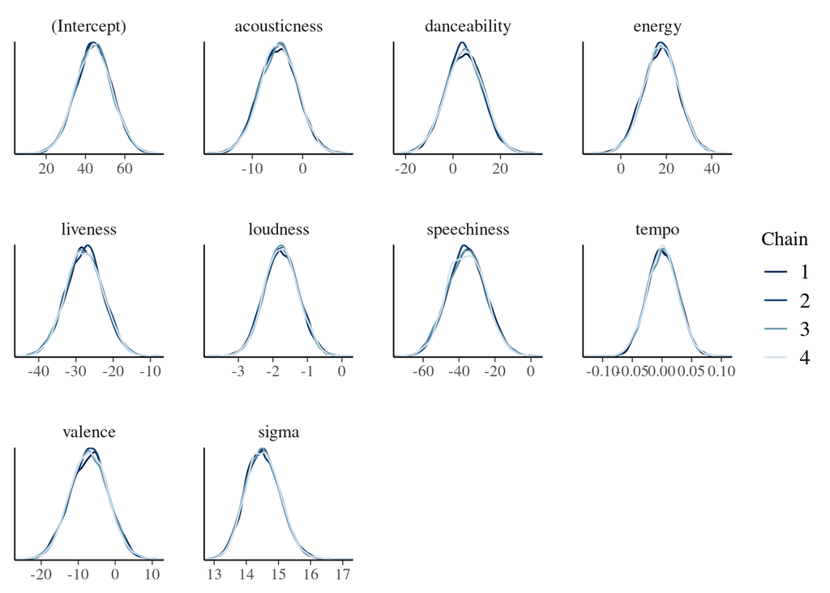

```r
mcmc_dens_overlay(taylor_model)
```

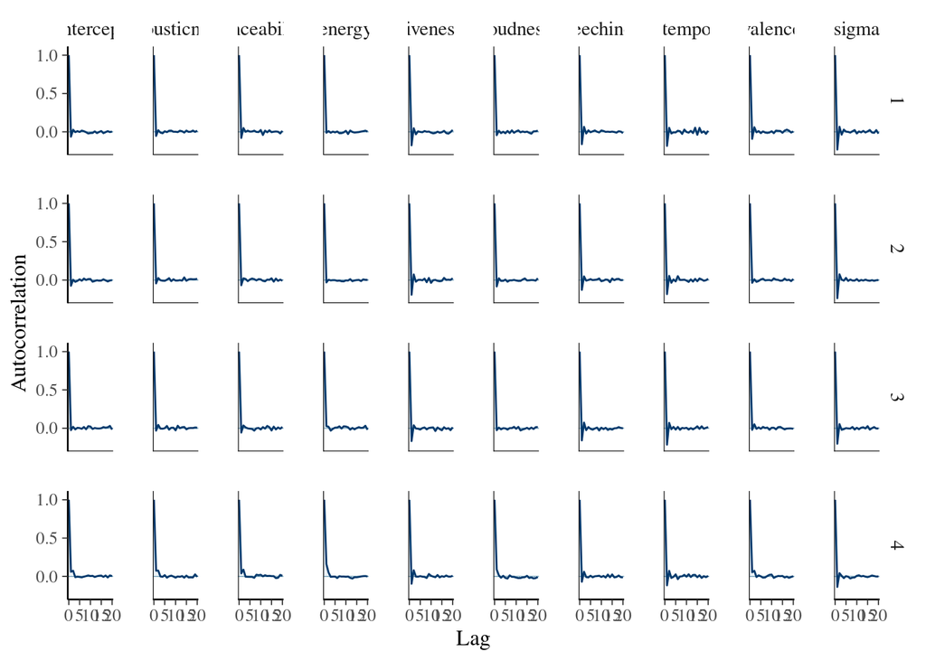

```r
mcmc_acf(taylor_model)
```

```r
rhat(taylor_model)
```

```
##  (Intercept) acousticness danceability       energy     liveness     loudness
##    0.9998278    0.9999147    0.9999565    0.9999435    0.9998847    0.9999295
##  speechiness        tempo      valence        sigma
##    0.9999872    0.9999182    0.9999690    0.9999378
```

```r
neff_ratio(taylor_model)
```

```
##  (Intercept) acousticness danceability       energy     liveness     loudness
##      1.01305      0.95645      0.97200      0.92110      1.29250      1.03355
##  speechiness        tempo      valence        sigma
##      1.18335      1.36770      0.97190      1.42060
```

The values of r-hat are very close to 1, so the parallel chains are consistent. The values of the effective sample size ratio are close to 1 and are higher than .1, which shows the chains are quality.

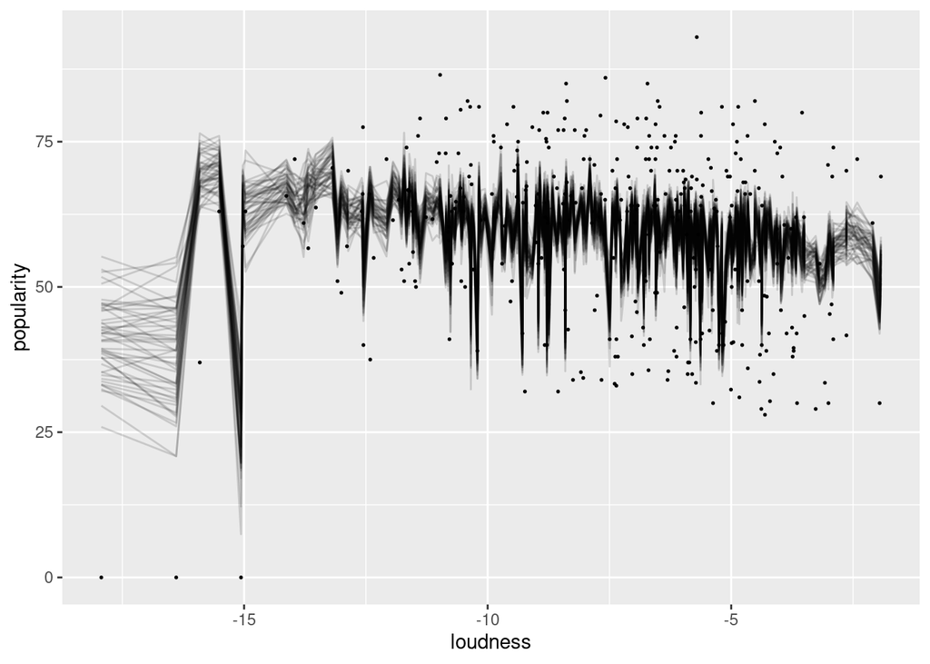

```r
taylor_final %>%
  add_epred_draws(taylor_model, ndraws = 50) %>% ggplot(aes(x= loudness, y= popularity)) + geom_line(aes(y=.epred, group=.draw), alpha= 0.15) + geom_point(data= taylor_final, size= 0.3)
```

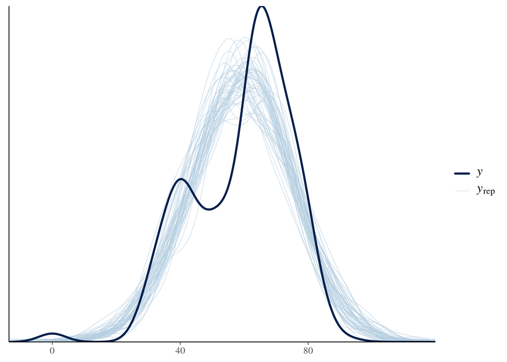

```r
pp_check(taylor_model)
```

The visual posterior predictive check suggests that the model captures the general center and spread of popularity fairly well, but fails to capture the multimodality of the data.

# Estimation of Regression Coefficients

```r
posterior_interval(taylor_model, prob= 0.90)
```

```
##                       5%         95%
## (Intercept)   29.1013548  59.5348318
## acousticness -11.0416709   1.4288864
## danceability  -8.4718654  17.7695786
## energy         4.7597157  30.5230151
## liveness     -36.0367659 -19.3752194
## loudness      -2.5689172  -0.9178408
## speechiness  -53.4153705 -17.9924419
## tempo         -0.0427932   0.0441502
## valence      -15.6143500   1.4262006
## sigma         13.6561440  15.4400316
```

When controlling for other model predictors, energy is the only variable positively associated with popularity. Liveness, loudness, and speechiness are negatively associated with popularity. Acousticness, danceablitiy, tempo, and valence are not significantly associated with popularity.

# Prediction and Interpretation

This model can be used to predict the popularity of a hypothetical new Taylor Swift song.

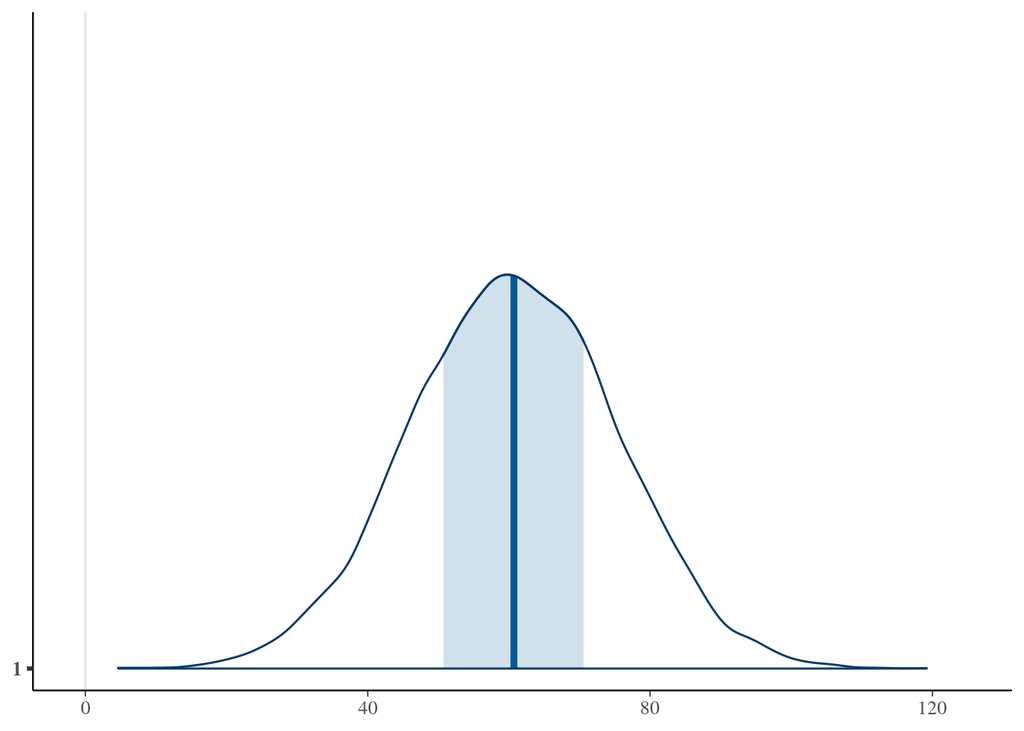

```r
predict_popularity <- posterior_predict(
  taylor_model, newdata = data.frame(acousticness= 0.05, danceability= 0.7,
        energy= 0.6, liveness= 0.2, loudness= -8.5, speechiness= 0.1, tempo= 115, valence= 0.5))
mcmc_areas(predict_popularity)
```

Based on this model, if she created a song with 0.05 acoustiness, 0.7 danceability, 0.6 energy, 0.2 liveness, -8.5 dB loudness, 0.1 speechiness, 115 bpm tempo and 0.5 valence, the most typical popularity of the song would be about 60, and its popularity would likely range from about 50 to 70.